# Projeti Final- Seri Kohore dhe Zbatime, Master shkencor IMI-2

Kembimi Valutor

Studenti:Gerald Cakoni Pedagogu:Eralda Gjika

24 Dhjetor, 2021

```r
colorize <- function(x, color) {
  if (knitr::is_latex_output()) {
    sprintf("\\textcolor{%s}{%s}", color, x)
  } else if (knitr::is_html_output()) {
    sprintf("<span style='color: %s;'>%s</span>", color,
      x)
  } else x
}
```

## Projekti final

### Hyrje

Qëllimi i këtij projekti është parashikimi i kursit të këmbimit të lekut kundrejt euros. Kembimi Valutor eshte nje koncept shumë i rendësishëm ne ekonomi pasi në varësi të tij meren shumë vendime për investime strategjike, import dhe eksport mallrash. Ne vendin tone euro ka patur shumë luhatja si rezultat i ndryshimeve drastike që kanë ndodhur dhe kjo e bën ndoshta më të vështire parashikimin, por padyshim më të nevojshëm. Disa arsye kryesore që kane ndikuar kursin e këmbimit janë: Rritja e numrit të madh të udhëtarëve,rritja e import-eksportit me vendet ku përdoret euro, paratë e pista dhe pastrimi i tyre etj. Duke perdorur modelet ARIMA,SARIMA dhe modele të ML per te parashikuar serine kohore me sa më pak gabime dhe me model sa më të përshtatshëm. Do zgjedhim ate model gabim sa më të vogel qe parashikon më saktë.

```r
library(ggplot2)
library(dplyr)
library(h2o)
library(forecast)
library(hrbrthemes)
library(fpp3)
library(vip)
library(randomForest)
library(Metrics)
library(ggplot2)
library(quantmod)
library(corrplot)
library(ggpubr)
library(PerformanceAnalytics)
library(MTS)
library(tibble)
library(gridExtra)
library(dplyr)
library(TSstudio)
library(tidytext)
library(tidyr)
library(tidyverse)
library(jsonlite)
library(widyr)
library(igraph)
library(ggraph)
library(stringr)
library(tm)
set.seed(1234)
```

### Përpunimi i të dhënave

Përpunimi

Importimi i të dhënave

```r
setwd(choose.dir())
te_dhena<-read.csv("Databaza.csv") # Lexo të dhënat
#View(te_dhena) #Shiko të dhënat
class(te_dhena$kembimi_valutor) #Shiko ca lloji është variabli
```

```
[1] "numeric"
```

```r
view(te_dhena)
```

#### Seritë kohore

Ndërtoj seri kohore për secilën variabël që kam marrë në studim

```r
ick.ts<-ts(te_dhena$ick,start =c(2016,1),frequency = 12) # Indeksi i Cmimeve të Konsumit
norma_depozitave.ts<-ts(te_dhena$norma_depozitave,start =c(2016,1),frequency = 12) # Norma e depozitave në lekë
norma_huave_euro.ts<-ts(te_dhena$norma_huave_euro,start =c(2016,1),frequency = 12)  # Norma e depozitave në euro
depozita_euro.ts<-ts(te_dhena$depozita_euro,start =c(2016,1),frequency = 12)  # Totali i depozitave në euro
depozita_lek.ts<-ts(te_dhena$depozita_lek,start =c(2016,1),frequency = 12)  # Totali i depozitave në lekë
shpenzimet_qeverise.ts<-ts(te_dhena$shpenzimet_qeverise,start =c(2016,1),frequency = 12)  # Shpenzimet e qeverisë në lekë
ivt.ts<-ts(te_dhena$ivt,start =c(2016,1),frequency = 12)  # Indeksi i vleres në tregti
hyrje.ts<-ts(te_dhena$hyrje,start =c(2016,1),frequency = 12)  # Hyrjet e shtetaseve në Shqipëri
dalje.ts<-ts(te_dhena$dalje,start =c(2016,1),frequency = 12)  # Daljet e shtetaseve në Shqipëri
importe.ts<-ts(te_dhena$importe,start =c(2016,1),frequency = 12)  # Importet në milion lekë
eksporte.ts<-ts(te_dhena$eksporte,start =c(2016,1),frequency = 12)  # Eksportet në milion lekë
diferenca_hyrje_dalje.ts<-ts(te_dhena$diferenca_hyrje_dalje,start =c(2016,1),frequency = 12) #Diferenca hyrje dalje te udhetareve
kembimi_valutor.ts<-ts(te_dhena$kembimi_valutor,start=c(2016,1),frequency = 12)
```

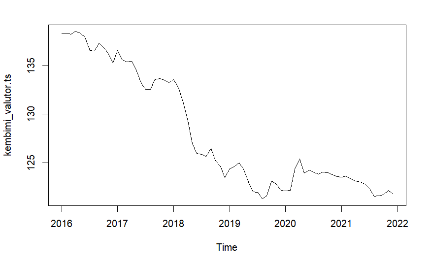

```r
#Paraqitjet grafike të serive

plot.ts(kembimi_valutor.ts) #Ndërto grafikun e serise kohore
```

Nga grafiku nuk dallohet një sezonalitet, por vëmë re që kemi një trend të dukshëm në rënie deri në vitin 2020, pastaj trendi zbutet disi. Kjo ka ardhur si pasojë e pandemisë sepse numri i udhetarëve drejt Shqipërise si edhe i depozitave dhe investimeve ra ndjeshëm.

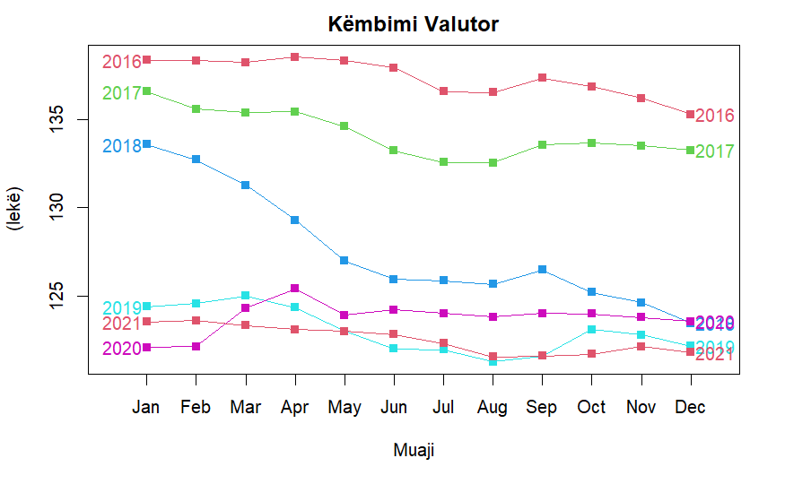

```r
seasonplot(kembimi_valutor.ts, ylab = "(lekë)", xlab = "Muaji",main = "Këmbimi Valutor",year.labels = TRUE,year.labels.left= TRUE, col = 2:6, pch=15)
```

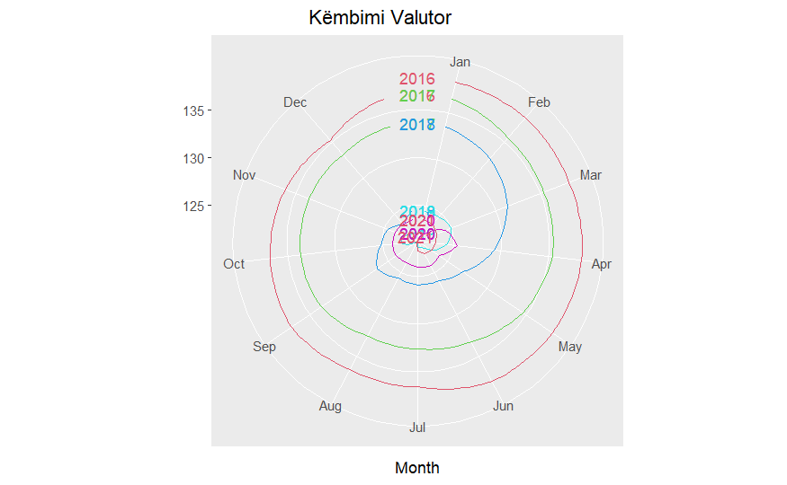

```r
ggseasonplot(kembimi_valutor.ts,main = "                  Këmbimi Valutor",year.labels = TRUE, year.labels.left = TRUE, col = 2:6, pch=15, polar=TRUE)
```

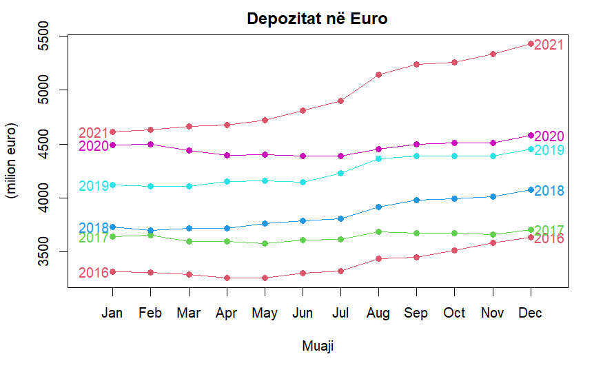

```r
seasonplot(depozita_euro.ts, ylab = "(milion euro)", xlab = "Muaji",main = "Depozitat në Euro",year.labels = TRUE, year.labels.left = TRUE, col = 2:6, pch=19)
```

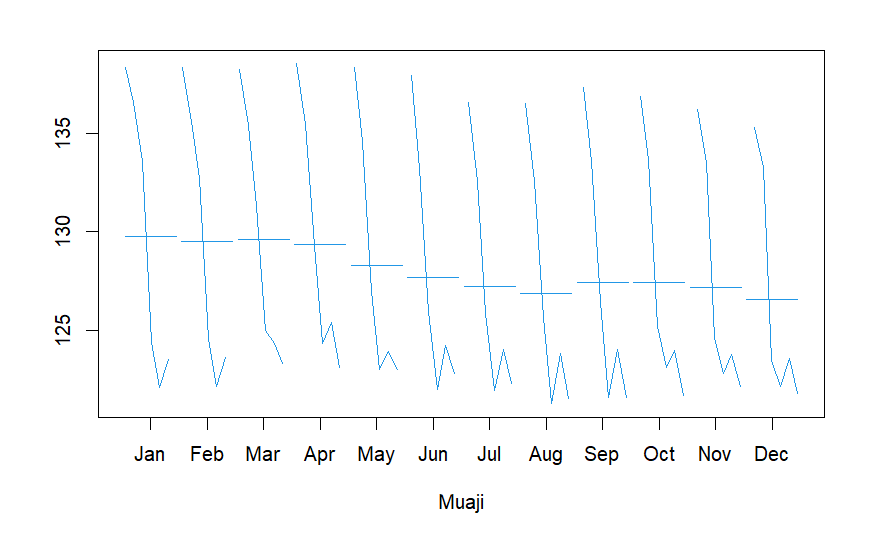

```r
monthplot(kembimi_valutor.ts, ylab = "", xlab = "Muaji", xaxt="n",main="", col=4)
axis(1, at = 1:12, labels = month.abb, cex=0.8)
```

Sipas paraqitjes në grafik arrijmë të dallojmë se kursi i këmbimit është më i lartë në janar (Largim i emigrantëve dhe depozitimi i euros në bankat e nivelit t dytë janë në nivele të larta gjithashtu) ndërsa ulet ndejshëm në muajit gusht dhe dhjetor. Shihet gjithashtu që në muajit kur kemi ulje të depozitave në euro kursi i këmbimit është më i lartë, ndërsa hyrjet e udhëtarëve ndikojnë disi më pak dhe nuk ndikojnë menjëherë, por mund të japin efekt në muajin pasardhës.

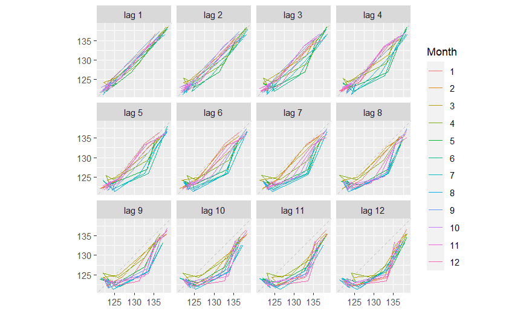

```r
gglagplot(kembimi_valutor.ts,12)
```

Në grafik paraqiten autokorrelacionet për 12 lage tëndryshme dhe kemi nje korrelacion të fortë dhe pozitiv që në lagun e parë, kjo tregon që të dhenat janë të lidhura fort dhe jo të rastësishme.

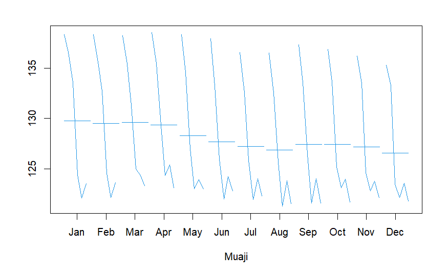

```r
monthplot(kembimi_valutor.ts, ylab = "", xlab = "Muaji", xaxt="n",main="", col=4)
axis(1, at = 1:12, labels = month.abb, cex=0.8)
```

Në këtë grafik paraqiten grafikët e ndarë për secilin muajin. Vija e drejtë në grafik tregon komponenten mesatare në muajin përkatës. Shihet se edhe duke marë mesataren e muajve kursi i këmbimit është në rënie gjatë gjithë vitit me një rritje të lehtë në shtator dhe tetor.

#### Korrelacioni

```r
cor.mat=cor(te_dhena[,c(2,3,5,6,7,9)])# correlation matrix
cor.mat
chart.Correlation(te_dhena[,c(2,3,4,5,6,7,8,9,10,11,12,13,14)], histogram=TRUE, pch=19)
```

[output not shown]

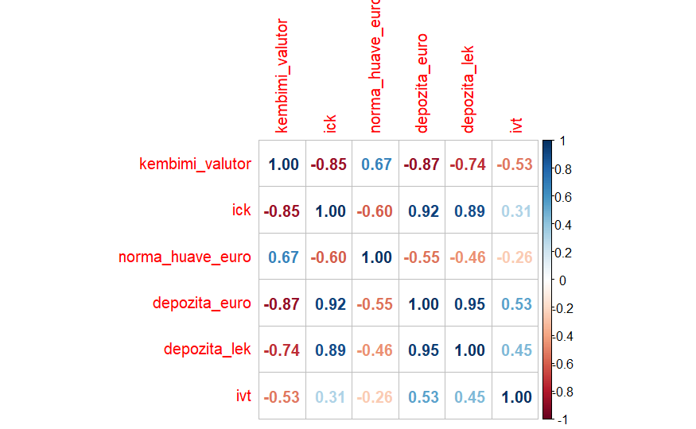

```r
corrplot(cor.mat, method="number")
```

Nga ky grafik i korrelacioneve midis variablave arrijmë të dallojmë te gjitha variablat që kanë korrelacion të fortë midis tyre. Variabli që ndikon më tepër tek këmbimi valutor është “Depozita ne Euro”. Ky variabël e shpjegon më mirë këmbimin valutor. Një tjetër variabël që ndikon shumë është “Indeksi i Cmimeve te Konsumit”, por ky është gjithashtu i korreluar me “Depozita ne Euro”. Pra modeli nuk duhet te jete i përbëre nga këta dy variabla njëkohësisht sepse ndikojnë negativisht në mirësinë e modelit.

### Analiza e të dhënave

Analiza

```r
summary(te_dhena)
```

[output not shown]

Të dhëna trajnuese dhe testuese. Të dhënat duhet ti ndajmë në dy grupe, testuese dhe trajnuese. Fillimisht do të ndërtojmë një model mbi të dhënat trajnuese dhe do të parashikojmë për pjesën e fundit të të dhënave (Të dhëna testuese). Nga krahasimi i këtyre të dhënave, pra këtyre të parashikuara dhe atyre reale (testuese) që të kuptojmë nëse modeli është i përshtatshëm për këto të dhëna.

```r
train_1 <-head(te_dhena,48) #66.6% e të dhënave
test_1 <-tail(te_dhena,24)  #33.3% e të dhënave
```

#### Transformimi i të dhënave

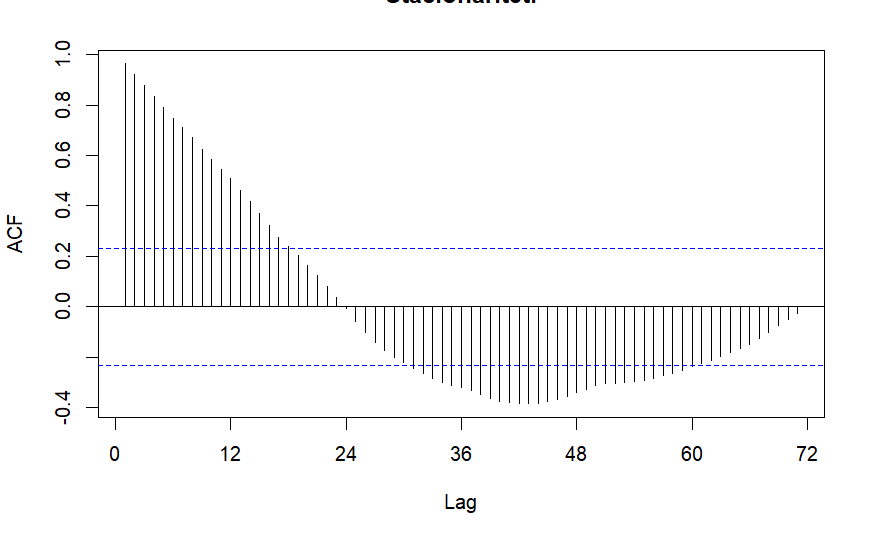

```r
Acf(kembimi_valutor.ts,72,main="Stacionariteti")
```

Seria nuk është stacionare pra ne duhet ta stacionarizojmë për të ndërtuar modele sa më të përshtatshme. Diferencimi i serisë e bën atë stacionare dhe heq ose redukton trendin dhe sezonalitetin.

```r
drift.f <- rwf(trajnimi$kembimi_valutor, h=32, drift = T) #
summary(drift.f)
```

[output not shown]

```r
train_kembimi_valutor<-head(kembimi_valutor.ts,48)
test_kembimi_valutor<-tail(kembimi_valutor.ts,24)
```

Diferencimi i serisë bëhet me komandat e mëposhtme:

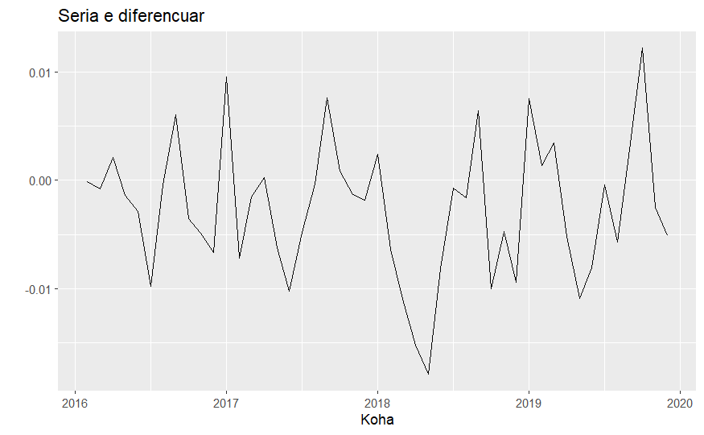

```r
#Logaritmet perkatese te serise per te stabilizuar dispersionin
log.te_dhena<-log(train_kembimi_valutor)

#Derivati i redit tee paree peer tee stacionarizuar tee dheenat
difflog.te_dhena <- (diff(log.te_dhena))

#Diferencimi Sezonal

Sezdifflog.te_dhena <- (diff(difflog.te_dhena,12))
#Plots
autoplot(difflog.te_dhena, main="Seria e diferencuar",xlab="Koha",ylab="")
```

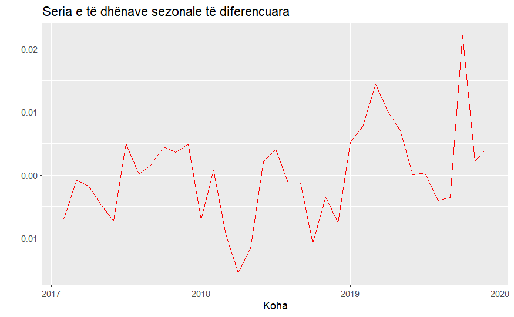

```r
autoplot(Sezdifflog.te_dhena,main="Seria e të dhënave sezonale të diferencuara",xlab="Koha",ylab="",col="red")
```

#### Ndërtimi i modelit

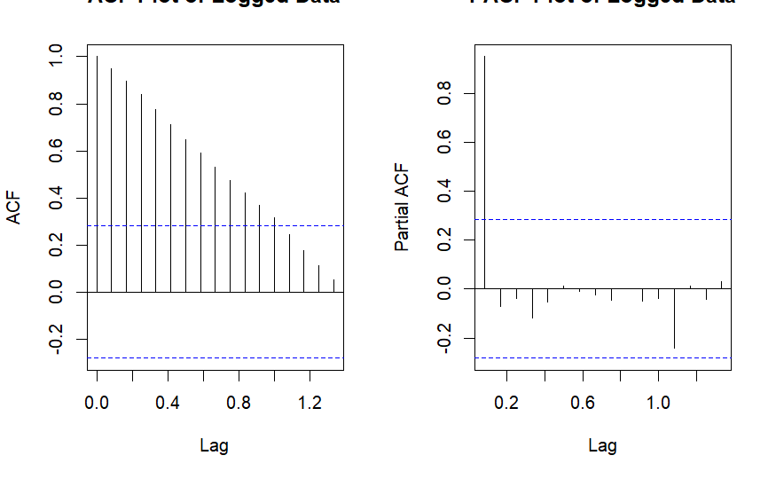

```r
par(mfrow=c(1,2))
acf(log.te_dhena, main = "ACF Plot of Logged Data")
pacf(log.te_dhena, main ="PACF Plot of Logged Data")
```

#### Modelet ARMA dhe ARIMA

```r
Modeli_ARMA <- arima(log.te_dhena, order=c(1,0,3)) # Modeli ARMA
Modeli_ARIMA<- arima(log.te_dhena, order=c(0,1,0)) # Modeli ARIMA

# Parashikimi për 2 vite, aq sa janë të dhënat testuese
ARMA_Parashikim <- predict(Modeli_ARMA, n.ahead = 2*12)
ARIMA_Parashikim <- predict(Modeli_ARIMA, n.ahead = 2*12)

#Kthejmë të dhënat nga logaritmike në decimale
ARMA_Parashikim1 <- 2.7182^ARMA_Parashikim$pred
ARIMA_Parashikim1 <- 2.7182^ARIMA_Parashikim$pred

# Ndërtoj grafikët përkatës
ts.plot(log.te_dhena, main = "Përshtatja sipas ARMA dhe ARIMA", xlab="Koha", ylab="Këmbimi Valutor", col="green")
ARMA_fit <- log.te_dhena - resid(Modeli_ARMA)
ARIMA_fit <- log.te_dhena - resid(Modeli_ARIMA)
points(ARMA_fit, type = "l", col= "blue", lty = 2)
```

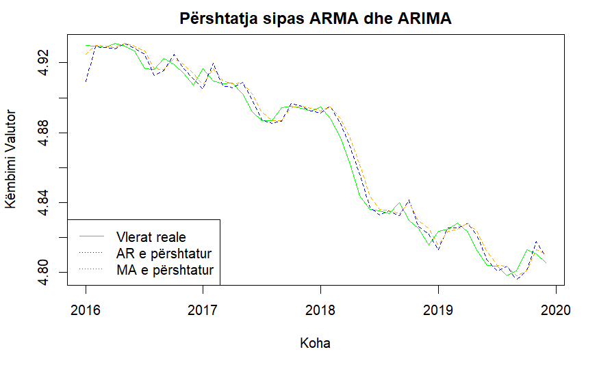

```r
points(ARIMA_fit, type = "l", col = "orange", lty = 2)
legend("bottomleft", legend = c("Vlerat reale","AR e përshtatur", "MA e përshtatur"), col = c("green","blue","red"), lty = c(1,3,3))
```

Pasi modeli është përshtatur me vlerat reale mund të përdoret për të parashikuar vlerat e ardhshme. Vlerat e ardhshme do të krahasohen me vlerat reale për të vlerësuar saktësine e modelit.

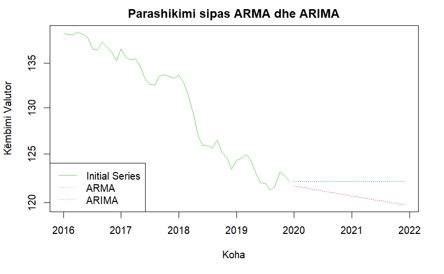

```r
ts.plot(train_kembimi_valutor, ARMA_Parashikim1, ARIMA_Parashikim1, log = "y", lty = c(1,3,3), main="Parashikimi sipas ARMA dhe ARIMA", xlab="Koha", ylab="Këmbimi Valutor", col= c(3,2,4))
legend("bottomleft", legend = c("Initial Series","ARMA", "ARIMA"), col = c(3,2,4), lty = c(1,3,3))
```

```r
Modeli_SARIMA <- arima(log.te_dhena, order=c(0,1,1)) # Modeli AR

# Parashikimi për 2 vite, aq sa janë të dhënat testuese
SARIMA_Parashikim <- predict(Modeli_SARIMA, n.ahead = 2*12)

#Kthejmë të dhënat nga logaritmike në decimale
SARIMA_Parashikim1 <- 2.7182^SARIMA_Parashikim$pred

# Ndërtoj grafikët përkatës
ts.plot(log.te_dhena, main = "Përshtatja sipas SARIMA", xlab="Koha", ylab="Këmbimi Valutor", col="green")
SARIMA_fit <- log.te_dhena - resid(Modeli_SARIMA)
points(SARIMA_fit, type = "l", col = "orange", lty = 2)
```

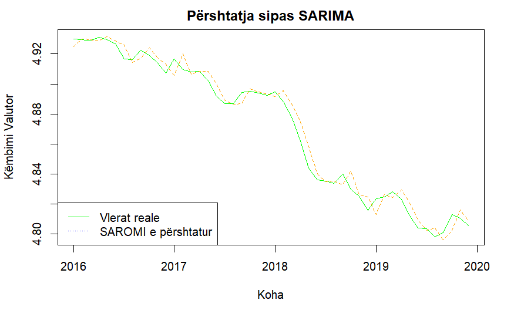

```r
legend("bottomleft", legend = c("Vlerat reale","SAROMI e përshtatur"), col = c("green","blue","red"), lty = c(1,3,3))
```

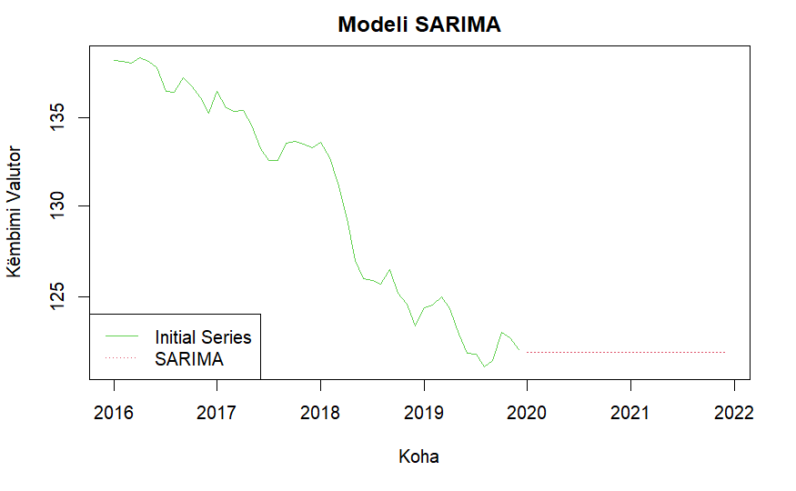

```r
ts.plot(train_kembimi_valutor, SARIMA_Parashikim1, log = "y", lty = c(1,3,3), main="Modeli SARIMA", xlab="Koha", ylab="Këmbimi Valutor", col= c(3,2,4))
legend("bottomleft", legend = c("Initial Series","SARIMA"), col = c(3,2,4), lty = c(1,3,3))
```

```r
te_dhena <-as.tibble(te_dhena)
trajnimi<-head(te_dhena,48)
testimi<-tail(te_dhena,24)

trajnimi$kembimi_valutor=scale(trajnimi$kembimi_valutor,center = TRUE)
trajnimi$ick=scale(trajnimi$ick,center = TRUE)
trajnimi$norma_depozitave=scale(trajnimi$norma_depozitave,center = TRUE)
trajnimi$norma_huave_euro=scale(trajnimi$norma_huave_euro,center = TRUE)
trajnimi$depozita_euro=scale(trajnimi$depozita_euro,center = TRUE)
trajnimi$depozita_lek=scale(trajnimi$depozita_lek,center = TRUE)
trajnimi$shpenzimet_qeverise=scale(trajnimi$shpenzimet_qeverise,center = TRUE)
trajnimi$ivt=scale(trajnimi$ivt,center = TRUE)
trajnimi$hyrje=scale(trajnimi$norma_depozitave,center = TRUE)


testimi$kembimi_valutor=scale(testimi$kembimi_valutor,center = TRUE)
testimi$ick=scale(testimi$ick,center = TRUE)
testimi$norma_depozitave=scale(testimi$norma_depozitave,center = TRUE)
testimi$norma_huave_euro=scale(testimi$norma_huave_euro,center = TRUE)
testimi$depozita_euro=scale(testimi$depozita_euro,center = TRUE)
testimi$depozita_lek=scale(testimi$depozita_lek,center = TRUE)
testimi$shpenzimet_qeverise=scale(testimi$shpenzimet_qeverise,center = TRUE)
testimi$ivt=scale(testimi$ivt,center = TRUE)
testimi$hyrje=scale(testimi$norma_depozitave,center = TRUE)
```

Do të përdorim metodën H2O për të analizuar se cila nga variablat ndikon më tepër tek Këmbimi Valutor.

```r
h2o.init(max_mem_size = "16G")
```

[output not shown]

```r
h2o.no_progress()
```

```r
y <- "kembimi_valutor"


x <- setdiff(names(train_1 %>% as.h2o()),c(y,"Muaji"))
```

```r
# random forest model
rft_model <-
  h2o.randomForest(
    x = x,
    y = y,
    training_frame = train_1 %>% as.h2o(),
    nfolds = 10,
    ntrees = 500,
    stopping_metric = "RMSE",
    stopping_rounds = 10,
    stopping_tolerance = 0.005,
    seed = 1975
  )
```

```r
# gradient boosting machine model
gbm_model <-
  h2o.gbm(
    x = x,
    y = y,
    training_frame = as.h2o(train_1),
    nfolds = 10,
    ntrees = 500,
    stopping_metric = "RMSE",
    stopping_rounds = 10,
    stopping_tolerance = 0.005,
    seed = 1975
  )

# geleralised linear model (a.k.a. elastic net model)
glm_model <-
  h2o.glm(
    x = x,
    y = y,
    training_frame = as.h2o(train_1),
    nfolds = 10,
    family = "gaussian",
    seed = 1975
  )
```

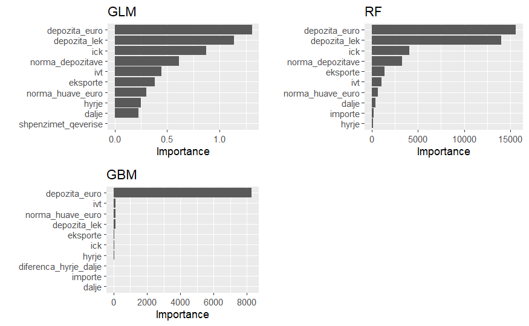

```r
p_glm <- vip(glm_model) + ggtitle("GLM")
p_rft <- vip(rft_model) + ggtitle("RF")
p_gbm <- vip(gbm_model) + ggtitle("GBM")


grid.arrange(p_glm, p_rft, p_gbm, nrow = 2)
```

```r
set.seed(100)
rf = randomForest(kembimi_valutor~depozita_euro+ick, data = trajnimi)
print(rf)
```

[output not shown]

```r
parashikime = predict(rf, newdata = trajnimi)
MAPE(trajnimi$kembimi_valutor, parashikime)
```

```
[1] 145.5146
```

```r
parash = predict(rf, newdata = testimi)
MAPE(testimi$kembimi_valutor, parash)
```

```
[1] 111.7983
```

```r
varImpPlot(rf)
```

[output not shown]

#### Model me Rrjeta Nervore

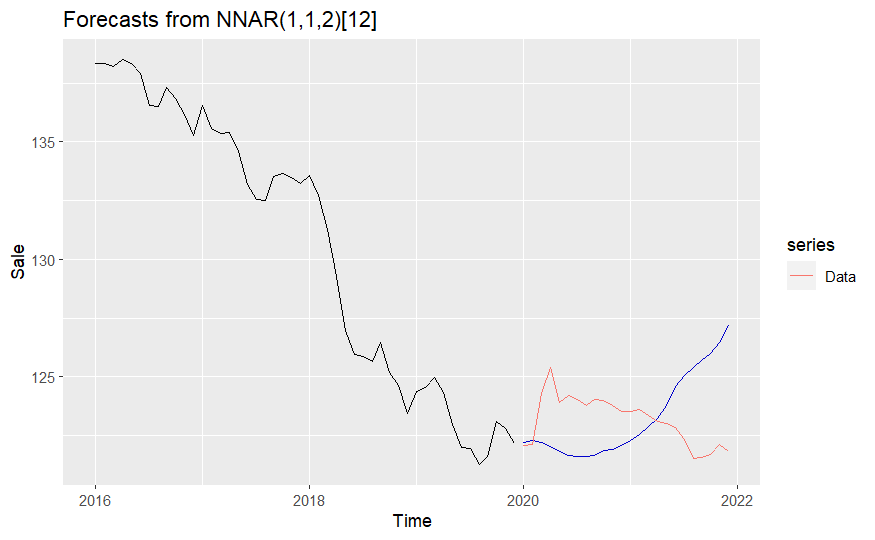

```r
nn.f4 = nnetar(ts(train_1$kembimi_valutor,start=2016,frequency = 12), xreg = ts(train_1$depozita_euro,start=2016,frequency = 12))
nn.f4.f <- forecast(nn.f4, xreg = ts(test_1$depozita_euro,start=c(2020,1),frequency=12), PI = F)
autoplot(nn.f4.f)+ylab("Sale")+
autolayer(ts(test_1$kembimi_valutor,start=c(2020,1),frequency = 12),series="Data")
```

```r
summary(nn.f4)
```

```
          Length Class        Mode
x         48     ts           numeric
m          1     -none-       numeric
p          1     -none-       numeric
P          1     -none-       numeric
scalex     2     -none-       list
scalexreg  2     -none-       list
size       1     -none-       numeric
xreg      48     -none-       numeric
subset    48     -none-       numeric
model     20     nnetarmodels list
nnetargs   0     -none-       list
fitted    48     ts           numeric
residuals 48     ts           numeric
lags       2     -none-       numeric
series     1     -none-       character
method     1     -none-       character
call       3     -none-       call
```

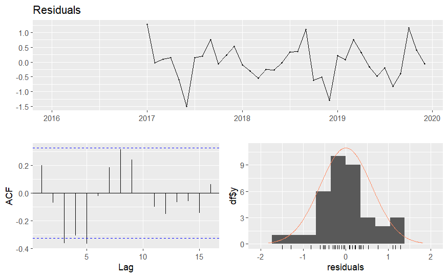

```r
checkresiduals(nn.f4$residuals)
```

```r
Box.test(x = nn.f4$residuals)
```

```
    Box-Pierce test

data:  nn.f4$residuals
X-squared = 1.4409, df = 1, p-value = 0.23
```

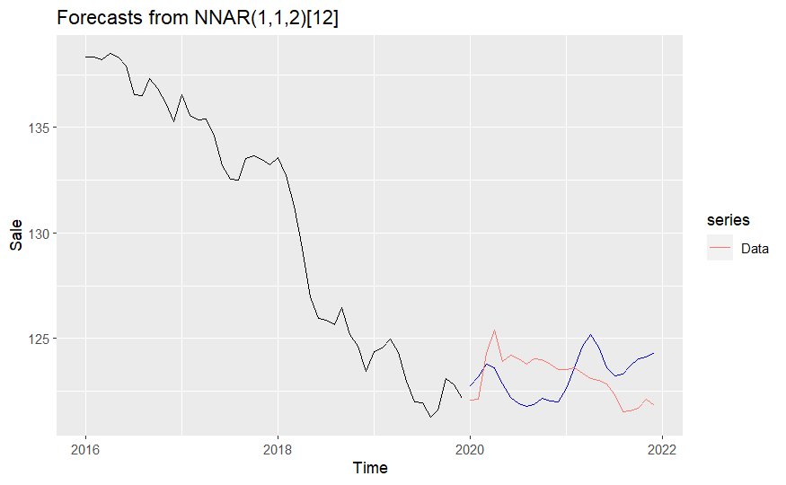

```r
nn.f4 = nnetar(ts(train_1$kembimi_valutor,start=2016,frequency = 12), xreg = ts(train_1$ick,start=2016,frequency = 12))
nn.f4.f <- forecast(nn.f4, xreg = ts(test_1$ick,start=c(2020,1),frequency=12), PI = F)
autoplot(nn.f4.f)+ylab("Sale")+
autolayer(ts(test_1$kembimi_valutor,start=c(2020,1),frequency = 12),series="Data")
```

```r
summary(nn.f4)
```

```
          Length Class        Mode
x         48     ts           numeric
m          1     -none-       numeric
p          1     -none-       numeric
P          1     -none-       numeric
scalex     2     -none-       list
scalexreg  2     -none-       list
size       1     -none-       numeric
xreg      48     -none-       numeric
subset    48     -none-       numeric
model     20     nnetarmodels list
nnetargs   0     -none-       list
fitted    48     ts           numeric
residuals 48     ts           numeric
lags       2     -none-       numeric
series     1     -none-       character
method     1     -none-       character
call       3     -none-       call
```

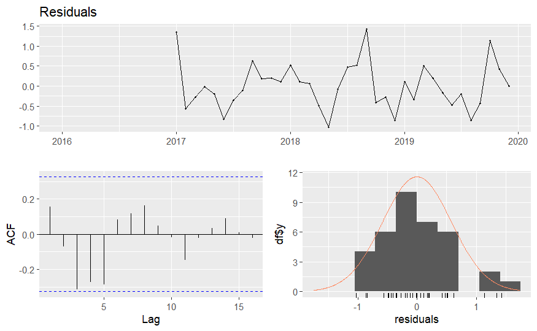

```r
checkresiduals(nn.f4$residuals)
```

```r
Box.test(x = nn.f4$residuals)
```

```
    Box-Pierce test

data:  nn.f4$residuals
X-squared = 0.87415, df = 1, p-value = 0.3498
```

```r
#mse(test_1$kembimi._valutor,sarima.f)
```

Në këtë grafik është përdorur Indeksi i Cmimeve të Konsumit për të parashikuar Këmbimin Valutor. Vëmë re që parashikimi në këtë rast është më i përafërt. Kjo ndodh sepse Indeksi i cmimit të konsumeve nuk u ndikua nga pandemia ose u ndikua shumë pak. Prandaj dhe modeli është më i saktë.

### Mirësia e modeleve

Miresia-gabimet

Vlëresoj modelin më të mirë.

```r
ARMA=summary(Modeli_ARMA)
ARIMA=summary(Modeli_ARIMA)
SARIMA=summary(Modeli_SARIMA)
Final = as.data.frame(t(c(ARMA$aic,ARIMA$aic,SARIMA$aic)))
Final %>% rename(
    ARMA_aic = V1,
    ARIMA_aic = V2,
    SARIMA_aic = V3)
```

| ARMA_aic | ARIMA_aic | SARIMA_aic |
| --- | --- | --- |
| -325.589 | -334.0596 | -337.5918 |

aic(ARMA)=-325.589 aic(ARIMA)=-334.0596 aic(SARIMA)=-337.5918

Vlerën më të vogël të “aic” e ka modeli SARIMA

```r
Modeli_ARMA=mse(test_kembimi_valutor,ARMA_Parashikim1)
Modeli_ARIMA=mse(test_kembimi_valutor,ARIMA_Parashikim1)
Modeli_SARIMA=mse(test_kembimi_valutor,SARIMA_Parashikim1)
Final_1 = as.data.frame(t(c(Modeli_ARMA,Modeli_ARIMA,Modeli_SARIMA)))
Final_1 %>% rename(
    ARMA_mse = V1,
    ARIMA_mse = V2,
    SARIMA_mse = V3)
```

| ARMA_mse | ARIMA_mse | SARIMA_mse |
| --- | --- | --- |
| 6.5449 | 2.031436 | 2.296651 |

mse(ARMA)=6.5449  
mse(ARIMA)=2.031436  
mse(SARIMA)=2.296651

Kërkohet për modele të cilat kanë aic dhe mse sa më të vogël. Në këte rast ARIMA dhe SARIMA kanë të dyja vlera të përafëerta, njëra ka mse më të vogël dhe tjetra ka “AIC” më të vogël.Të dy këta modele janë më të mirë se ARMA dhe do përdoret njëri prej tyre. Meqenëse ndryshimi i “aic” është i papërfillshëm atëherë do të zgjedhim ARIMA si model më të mirë pasi ka “mse” më të vogël.

```r
perf_gbm_model <-
  h2o.performance(gbm_model, newdata = as.h2o(test_1))
perf_gbm_model %>% h2o.r2()
```

```
[1] -0.2390693
```

```r
perf_gbm_model %>% h2o.rmse()
```

```
[1] 1.127101
```

```r
perf_glm_model <-
  h2o.performance(glm_model, newdata = as.h2o(test_1))
perf_glm_model %>% h2o.r2()
```

```
[1] -45.75346
```

```r
perf_glm_model %>% h2o.rmse()
```

```
[1] 6.92344
```

```r
perf_rft_model <-
  h2o.performance(rft_model, newdata = as.h2o(test_1))
perf_rft_model %>% h2o.r2()
```

```
[1] -0.1977873
```

```r
perf_rft_model %>% h2o.rmse()
```

```
[1] 1.108166
```

rmse(GBM)=1.127101  
rmse(GLM)=6.9234  
rmse(RFT)=1.108166

RFT ka rmse më të vogël pra ai është modeli më i mirë për të treguar se cilat nga variablat janë më të rëndësishme në model. Edhe modeli që u ndërtua si korrelacion i Këmbimit Valutor me Indeksin e Cmimeve të Konsumit.

### Referenca

#### Databaza

http://www.instat.gov.al/  
https://www.bankofalbania.org/  
https://ec.europa.eu/eurostat

#### Website dhe libra të ndryshëm

Leksione: Autor - Llukan Puka  
Leksione: Autor - Eralda Gjika

“Forecasting: Principles and Practice (2nd ed)”, Rob J Hyndman and George Athanasopoulos - https://otexts.com/fpp3/  
“Time Series Analysis and Its Applications, With R Examples — 4th Edition” , SHUMWAY & STOFFER’S - https://www.stat.pitt.edu/stoffer/tsa4/  
https://rpubs.com/  
https://stackoverflow.com/

End